# Machine Learning con H2O y R

## Parámetros e hiperparámetros

Los modelos de *Deep Learning* ofrecidos por H2O tienen un número muy elevado de parámetros configurables ([listado](http://docs.h2o.ai/h2o/latest-stable/h2o-docs/data-science/deep-learning.html)). Para la gran mayoría de casos, los valores por defecto dan buenos resultados, sin embargo, es conveniente conocer, al menos, los más influyentes.

**Arquitectura**

- `hidden`: número de capas ocultas y número de neuronas por capa. La estructura se define mediante un vector de números enteros. Por ejemplo, una red con una única capa de 100 neuronas se crea con `hidden = c(100)`, y una red con dos capas ocultas de 10 neuronas cada una con `hidden = c(10, 10)`. Las capas de entrada y salida se crean automáticamente. La capa de entrada tiene tantas neuronas como predictores (tras codificar las variables categóricas). La capa de salida tiene una única neurona en problemas de regresión, y tantas neuronas como clases en los problemas de clasificación.

**Preprocesado**

- `standardize`: por defecto, se estandarizan los valores para que tengan media cero y varianza uno. Los modelos basados en redes no son independientes de la escala de los predictores, por lo que es fundamental estandarizarlos.
- `missing_values_handling`: las redes neuronales no aceptan observaciones con valores ausentes. H2O ofrece dos opciones: excluirlos `Skip` o imputarlos con la media `MeanImputation`.
- `shuffle_training_data`: mezclar aleatoriamente las observaciones antes de entrenar el modelo.

**Aprendizaje**

- `activation`: función de activación de las neuronas de las capas intermedias (*Tahn*, *Tahn with dropout*, *Rectifier*, *Rectifier with dropout*, *Maxout*, *Maxout with dropout*). Las funcines *Rectifier* y *Rectifier with dropout* suelen dar buenos resultados para un abanico muy grande de situaciones. La función de activación de la capa de salida se selecciona automáticamente dependiendo de si es un problema de regresión o clasificación.
- `loss`: función de coste que se intenta minimizar durante el entrenamiento de la red.
- `epochs`: número de veces que pasan todos los datos por la red durante su entrenamiento. Encontrar el valor óptimo de épocas es muy importante ya que, si son muy pocas, la red puede no aprender lo suficiente, pero si son demasiadas, se produce *overfiting*. Normalmente, se puede tener una idea aproximada del valor correcto en función de la complejidad de la red (cuanto más compleja más pesos hay que aprender) y el número de observaciones de entrenamiento. Gracias al sistema de *early stopping* implementado en H2O, se puede indicar un número muy elevado de épocas sin riesgo de *overfitting*, ya que el entrenamiento se detendrá cuando la métrica de validación elegida no mejore. Aun así, siempre es recomendable representar la evolución del error de entrenamiento y validación en función del número de épocas.
- `adaptive_rate`: si se indica esta opción (activada por defecto), se emplea el algoritmo (*ADADELTA*) como algoritmo de aprendizaje. Con él, se consigue que el *learning rate* se adapte automáticamente (reduciéndose) a medida que el entrenamiento avanza. Es recomendable probar en primer lugar esta opción, ya que consigue un balance entre velocidad de aprendizaje y resultados bastante bueno. Este algoritmo está controlado por dos parámetros:
  - rho: controla el ratio en el que se va reduciendo el *learning rate* en cada iteración de aprendizaje.
  - epsilon: corrector para evitar divisiones entre cero.

Si se desactiva el `adaptive_rate`, entonces, el usuario debe especificar qué valor de *learning rate* debe tener la red.

- `rate`: Cuanto menor sea este valor, más estable es el modelo final pero más tarda en aprender (llegar a convergencia).
- `nesterov_accelerated_gradient`: activa el método de descenso de gradiente *Nesterov Accelerated Gradient*.

**Regularización**

- `input_dropout_ratio`: porcentaje de *dropout* en la capa de entrada. Este tipo de regularización controla que ningún predictor influya en exceso en la red. Se recomiendan valores de 0.1 o 0.2.
- `hidden_dropout_ratios`: porcentaje de *dropout* en las capas de intermedias. Solo es aplicable si se selecciona como función de activación *TanhWithDropout*, *RectifierWithDropout*, o *MaxoutWithDropout*. Por defecto, el valor es 0.5.
- `l1`: penalización *l1*. Ver apartado de regularización GLM para más información.
- `l2`: penalización *l2*. Ver apartado de regularización GLM para más información.

El siguiente listado contiene el valor por defecto de cada uno de los argumentos de la función `h2o.deeplearning()`.

- `nfolds` = 0
- `keep_cross_validation_predictions` = FALSE
- `keep_cross_validation_fold_assignment` = FALSE
- `fold_assignment` = c(“AUTO”, “Random”, “Modulo”, “Stratified”)
- `fold_column` = NULL
- `ignore_const_cols` = TRUE
- `score_each_iteration` = FALSE
- `weights_column` = NULL
- `offset_column` = NULL
- `balance_classes` = FALSE
- `class_sampling_factors` = NULL
- `max_after_balance_size` = 5
- `max_hit_ratio_k` = 0
- `checkpoint` = NULL
- `pretrained_autoencoder` = NULL
- `overwrite_with_best_model` = TRUE
- `use_all_factor_levels` = TRUE
- `standardize` = TRUE
- `activation` = c(“Tanh”, “TanhWithDropout”, “Rectifier”, “RectifierWithDropout”, “Maxout”, “MaxoutWithDropout”)
- `hidden` = c(200, 200)
- `epochs` = 10
- `train_samples_per_iteration` = -2
- `target_ratio_comm_to_comp` = 0.05
- `seed` = -1
- `adaptive_rate` = TRUE
- `rho` = 0.99
- `epsilon` = 1e-08
- `rate` = 0.005
- `rate_annealing` = 1e-06
- `rate_decay` = 1
- `momentum_start` = 0
- `momentum_ramp` = 1e+06
- `momentum_stable` = 0
- `nesterov_accelerated_gradient` = TRUE
- `input_dropout_ratio` = 0
- `hidden_dropout_ratios` = NULL
- `l1` = 0
- `l2` = 0
- `max_w2` = 3.4028235e+38
- `initial_weight_distribution` = c(“UniformAdaptive”, “Uniform”, “Normal”)
- `initial_weight_scale` = 1
- `initial_weights` = NULL
- `initial_biases` = NULL
- `loss` = c(“Automatic”, “CrossEntropy”, “Quadratic”, “Huber”, “Absolute”, “Quantile”)
- `distribution` = c(“AUTO”, “bernoulli”, “multinomial”, “gaussian”, “poisson”, “gamma”, “tweedie”, “laplace”, “quantile”, “huber”)
- `quantile_alpha` = 0.5
- `tweedie_power` = 1.5
- `huber_alpha` = 0.9
- `score_interval` = 5
- `score_training_samples` = 10000
- `score_validation_samples` = 0
- `score_duty_cycle` = 0.1
- `classification_stop` = 0
- `regression_stop` = 1e-06
- `stopping_rounds` = 5
- `stopping_metric` = c(“AUTO”, “deviance”, “logloss”, “MSE”, “RMSE”, “MAE”, “RMSLE”, “AUC”, “lift_top_group”, “misclassification”, “mean_per_class_error”)
- `stopping_tolerance` = 0
- `max_runtime_secs` = 0
- `score_validation_sampling` = c(“Uniform”, “Stratified”)
- `diagnostics` = TRUE
- `fast_mode` = TRUE
- `force_load_balance` = TRUE
- `variable_importances` = TRUE
- `replicate_training_data` = TRUE
- `single_node_mode` = FALSE
- `shuffle_training_data` = FALSE
- `missing_values_handling` = c(“MeanImputation”, “Skip”)
- `quiet_mode` = FALSE
- `autoencoder` = FALSE
- `sparse` = FALSE
- `col_major` = FALSE
- `average_activation` = 0
- `sparsity_beta` = 0
- `max_categorical_features` = 2147483647
- `reproducible` = FALSE
- `export_weights_and_biases` = FALSE
- `mini_batch_size` = 1
- `categorical_encoding` = c(“AUTO”, “Enum”, “OneHotInternal”, “OneHotExplicit”, “Binary”, “Eigen”, “LabelEncoder”, “SortByResponse”, “EnumLimited”)
- `elastic_averaging` = FALSE
- `elastic_averaging_moving_rate` = 0.9
- `elastic_averaging_regularization` = 0.001
- `verbose` = FALSE

## Importancia de los predictores

Para modelos de redes neuronales, una forma de cuantificar la importancia de los predictores es mediante el método *Gedeon*. Por defecto, esta opción está desactivada debido a que puede ser un proceso muy lento.

## Modelo

```r
# Hiperparámetros que se quieren comparar.
hiperparametros <- list(hidden = list(c(64), c(128), c(256), c(512), c(1024),
                                      c(64,64), c(128,128), c(256,256),
                                      c(512, 512)))
grid_dl <- h2o.grid(
    # Algoritmo.
    algorithm = "deeplearning",
    activation = "RectifierWithDropout",
    epochs = 500,
    # Variable respuesta y predictores.
    y = var_respuesta,
    x = predictores,
    # Datos de entrenamiento.
    training_frame = datos_train_h2o,
    shuffle_training_data = FALSE,
    # Datos de validación.
    validation_frame = datos_val_h20,
    # Preprocesado.
    standardize = TRUE,
    missing_values_handling = "Skip",
    # Detención temprana.
    stopping_rounds = 3,
    stopping_metric = "AUC",
    stopping_tolerance = 0.01,
    # Hiperparámetros optimizados.
    hyper_params = hiperparametros,
    # Regularización
    l1 = 1e-5,
    l2 = 1e-5,
    # Tipo de búsqueda.
    search_criteria = list(strategy = "Cartesian"),
    seed = 123,
    grid_id = "grid_dl"
          )
```

```r
# Se muestran los modelos ordenados de mayor a menor AUC.
resultados_grid <- h2o.getGrid(grid_id = "grid_dl",
                               sort_by = "auc",
                               decreasing = TRUE)

data.frame(resultados_grid@summary_table) %>% select(-model_ids)
```

| hidden | auc |
| --- | --- |
| [1024] | 0.9276617468310471 |
| [512] | 0.9272982577993865 |
| [128] | 0.9268999082181926 |
| [512, 512] | 0.9261294371542679 |
| [256] | 0.9258018009078957 |
| [64] | 0.9255297298638157 |
| [64, 64] | 0.9244055267531566 |
| [256, 256] | 0.9233148942855489 |
| [128, 128] | 0.9226121267746551 |

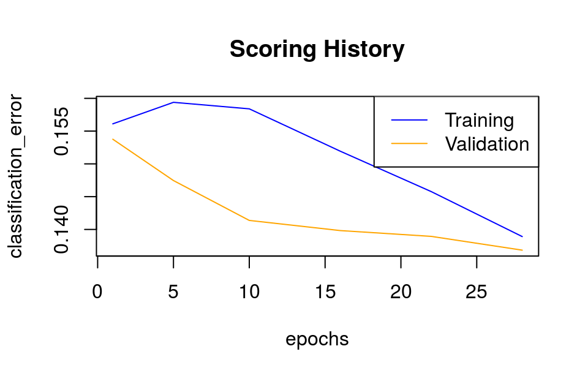

```r
modelo_dl_final <- h2o.getModel(resultados_grid@model_ids[[1]])
plot(modelo_dl_final, timestep = "epochs", metric = "classification_error")
```

```r
# AUC de test
h2o.performance(model = modelo_dl_final, newdata = datos_test_h2o)@metrics$AUC
```

```
## [1] 0.9128648
```

# Guardar un modelo H2O

Para guardar un modelo H2O ya entrenado se emplean la función `h2o.saveModel()`.

```r
# Se guarda el modelo en el directorio actual
h2o.saveModel(object = modelo_dl_final, path = getwd(), force = TRUE)
```

```
## [1] "/home/ximo/Documents/Estudios autodidácticos/Estadística_R programming/Apuntes personales/Estadística/grid_dl_model_4"
```

Para cargar un modelo previamente guardado se emplea la función `h2o.loadModel()`.

```r
# Se guarda el modelo en el directorio actual.
modelo <- h2o.loadModel(path = "./grid_dl_model_8")
```

```r
# Se apaga el cluster H2O.
h2o.shutdown(prompt = FALSE)
```

```
## [1] TRUE
```

# Bibliografía

Nykodym, T., Kraljevic, T., Hussami, N., Rao, A., and Wang, A. (Nov 2017). Generalized Linear Modeling with H2O

Gradient Boosting Machine with H2O by Michal Malohlava & Arno Candel with assitance from Cliff Click, Hank Roark, & Viraj Parmar

Machine Learning with R and H2O by Mark Landry with assistance from Spencer Aiello, Eric Eckstrand, Anqi Fu, & Patrick Aboyoun Edited by: Angela Bartz

Dua, D. and Karra Taniskidou, E. (2017). UCI Machine Learning Repository [http://archive.ics.uci.edu/ml]. Irvine, CA: University of California, School of Information and Computer Science

Practical Machine Learning with H2O by Darren Cook

[Top 10 Deep Learning Tips and Tricks - Arno Candel](https://www.youtube.com/watch?v=LM255qs8Zsk)

This work by Joaquín Amat Rodrigo is licensed under a [Creative Commons Attribution 4.0 International License](http://creativecommons.org/licenses/by/4.0/).